# Final Paper

STOR 320 Group 5

# INTRODUCTION

In today’s society, happiness is a term well know, however its definition might vary among individuals based on their nationality, identity, personal experiences and other factors. Following the COVID-19 pandemic and other meaningful events around the world, governments have had to take action in guaranteeing the happiness of every citizen and try to boost it in every possible manner. From a political and economic perspective, happiness constitute a leading factor in the development of every nation since it is directly proportional to the well-being of every worker, student, military member, etc. For this reason, every year a `World Happiness Report` is globally shared. It contains the data and overall ranking of countries’ happiness based on standard socio-economic factors.

Our research focuses on the identification of the relations between some of the future discussed factor and the overall happiness of each nation. For that we will be focusing on 2 Main Questions:

- How World Happiness has changed over the past years? Is it safe to assume that there is a region in the world more happy than another?
- What are the most influential factors in determining a country’s happiness? How unequal is the happiness distribution?

The previously mentioned questions will contribute to the overall understanding of governments priorities in regards to improving the countries happiness. In addition, the results of our questions might contribute to the global perspective of many individuals that seem to identify certain region of the world more happy that another.

# DATA

This study was conducted using a database from the World Happiness Report , which constitutes a landmark survey of the state of global happiness. The happiness scores and rankings use data from the Gallup World Poll. the Gallup World Poll is poll that continually surveys citizens in 160 countries, representing more than 98% of the world’s adult population. It contains global questions in addition to region-specific as well. The dataset used for this studies have gained global recognition as governments, organization and civil societies use it to inform their policy-making decisions.

The variables from the dataset that show the more relevance to our studies are:

- `Country name`, which corresponds to 149 unique values (countries)
- `Regional indicator`, showing the region the country belongs to.
- `Ladder score`, represents the overall happiness score of the country
- `Other varaibles` that contribute to the overall happiness ranking.
  - `Logged GDP Per Capita`
  - `Social Support`
  - `Healthy Life Expectancy`
  - `Freedom to Make Life Choices`
  - `Generosity`
  - `Perceptions of corruption`

## World Happiness Report Entire DataSet 2021

| Country.name | Regional.indicator | Ladder.score | Standard.error.of.ladder.score | upperwhisker | lowerwhisker | Logged.GDP.per.capita | Social.support | Healthy.life.expectancy | Freedom.to.make.life.choices | Generosity | Perceptions.of.corruption | Ladder.score.in.Dystopia | Explained.by..Log.GDP.per.capita | Explained.by..Social.support | Explained.by..Healthy.life.expectancy | Explained.by..Freedom.to.make.life.choices | Explained.by..Generosity | Explained.by..Perceptions.of.corruption | Dystopia...residual |
| --- | --- | --- | --- | --- | --- | --- | --- | --- | --- | --- | --- | --- | --- | --- | --- | --- | --- | --- | --- |
| Finland | Western Europe | 7.842 | 0.032 | 7.904 | 7.780 | 10.775 | 0.954 | 72.000 | 0.949 | -0.098 | 0.186 | 2.43 | 1.446 | 1.106 | 0.741 | 0.691 | 0.124 | 0.481 | 3.253 |
| Denmark | Western Europe | 7.620 | 0.035 | 7.687 | 7.552 | 10.933 | 0.954 | 72.700 | 0.946 | 0.030 | 0.179 | 2.43 | 1.502 | 1.108 | 0.763 | 0.686 | 0.208 | 0.485 | 2.868 |
| Switzerland | Western Europe | 7.571 | 0.036 | 7.643 | 7.500 | 11.117 | 0.942 | 74.400 | 0.919 | 0.025 | 0.292 | 2.43 | 1.566 | 1.079 | 0.816 | 0.653 | 0.204 | 0.413 | 2.839 |
| Iceland | Western Europe | 7.554 | 0.059 | 7.670 | 7.438 | 10.878 | 0.983 | 73.000 | 0.955 | 0.160 | 0.673 | 2.43 | 1.482 | 1.172 | 0.772 | 0.698 | 0.293 | 0.170 | 2.967 |
| Netherlands | Western Europe | 7.464 | 0.027 | 7.518 | 7.410 | 10.932 | 0.942 | 72.400 | 0.913 | 0.175 | 0.338 | 2.43 | 1.501 | 1.079 | 0.753 | 0.647 | 0.302 | 0.384 | 2.798 |
| Norway | Western Europe | 7.392 | 0.035 | 7.462 | 7.323 | 11.053 | 0.954 | 73.300 | 0.960 | 0.093 | 0.270 | 2.43 | 1.543 | 1.108 | 0.782 | 0.703 | 0.249 | 0.427 | 2.580 |
| Sweden | Western Europe | 7.363 | 0.036 | 7.433 | 7.293 | 10.867 | 0.934 | 72.700 | 0.945 | 0.086 | 0.237 | 2.43 | 1.478 | 1.062 | 0.763 | 0.685 | 0.244 | 0.448 | 2.683 |
| Luxembourg | Western Europe | 7.324 | 0.037 | 7.396 | 7.252 | 11.647 | 0.908 | 72.600 | 0.907 | -0.034 | 0.386 | 2.43 | 1.751 | 1.003 | 0.760 | 0.639 | 0.166 | 0.353 | 2.653 |
| New Zealand | North America and ANZ | 7.277 | 0.040 | 7.355 | 7.198 | 10.643 | 0.948 | 73.400 | 0.929 | 0.134 | 0.242 | 2.43 | 1.400 | 1.094 | 0.785 | 0.665 | 0.276 | 0.445 | 2.612 |
| Austria | Western Europe | 7.268 | 0.036 | 7.337 | 7.198 | 10.906 | 0.934 | 73.300 | 0.908 | 0.042 | 0.481 | 2.43 | 1.492 | 1.062 | 0.782 | 0.640 | 0.215 | 0.292 | 2.784 |

[output cut: 139 more lines]

# RESULTS

In order to answer our research questions it is necessary to understand our position in the World Happiness rank as of today.

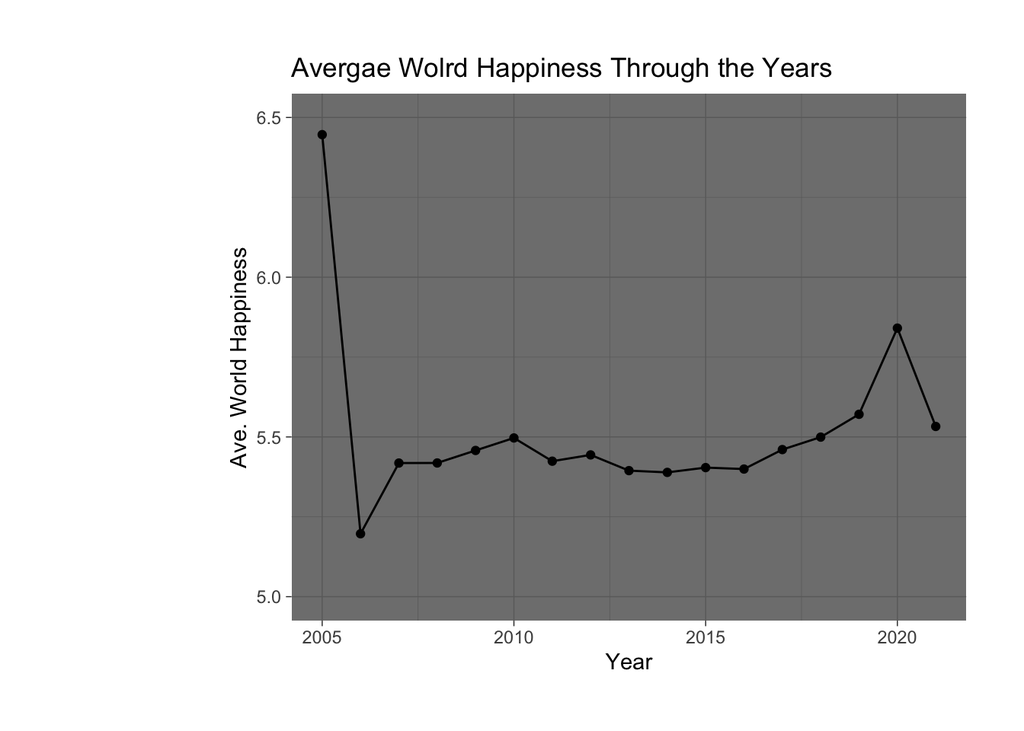

Notice that in 2021, the World Happiness scored and average of 5.53. However, since 2006, no significance change can be appreciated. This leads to the specific analysis of the happiness of each country. In this case we will looking at the top and bottom countries and their changes through time.

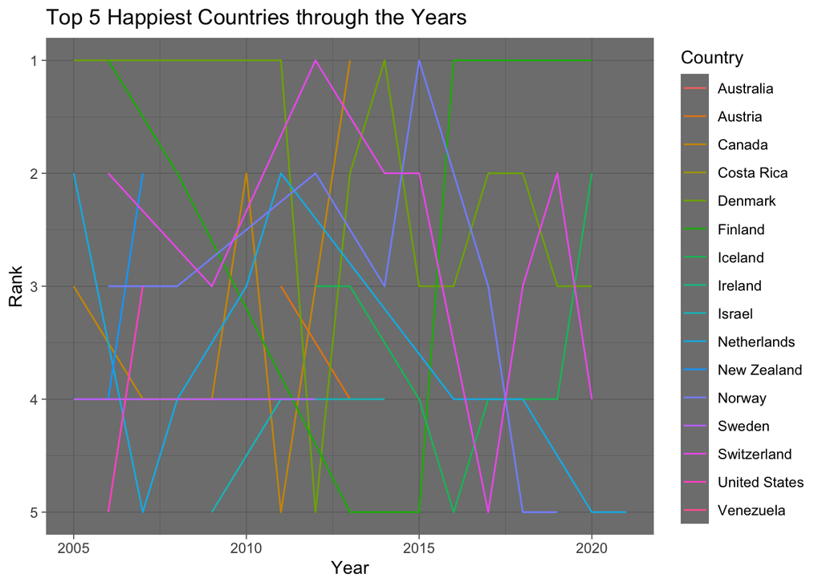

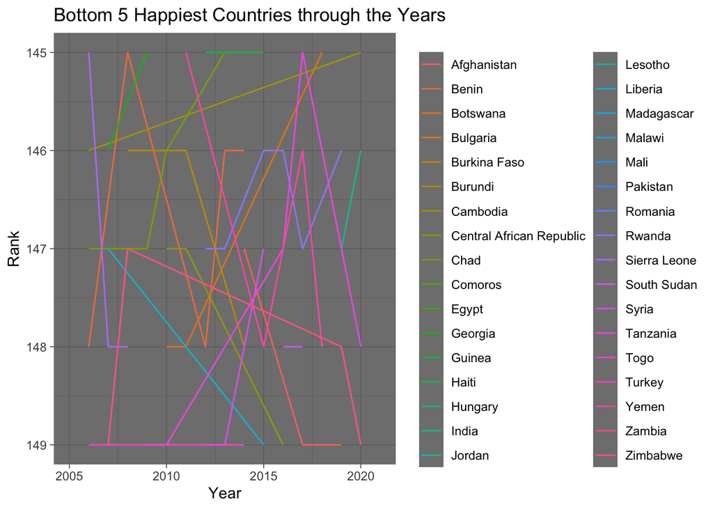

In the case of the `Top 5 Happiest Countries`, for most of the countries, there has just been an oscillation thought the years; for example Switzerland and Denmark. The `Bottom 5 Countries` shows more countries along the years, showing more unstability in this category.

In order to determine if there is a region of the o world that is generally happy than another region we are going to use the most recent data corresponding the `World Happinees Report 2021`. Using ANOVA, we are going to determine if the differences among the different regions are statistically significant or not.

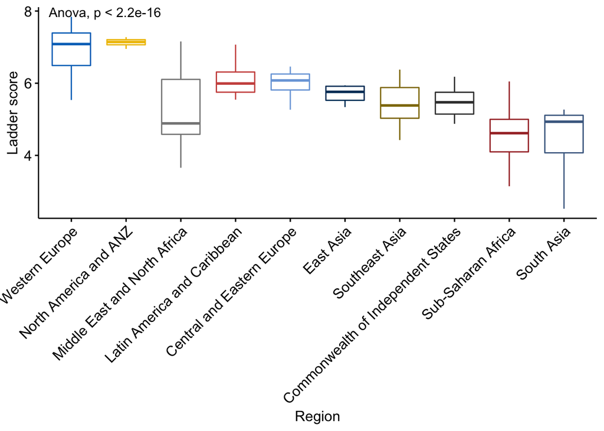

# Multiple Regression Model for the other Question